# Final Project

BIOS 635

4/3/2021

# Libraries

```r
library(tidyverse)
library(haven)
library(magrittr)
library(caret)
library(pROC)
library(e1071)
library(mice)
library(doParallel)
library(tictoc)
library(furrr)
```

```r
library(beepr)
library(plotrix)
library(gtsummary)
library(flextable)
library(OptimalCutpoints)
library(DMwR)
```

# Import

```r
datasets <- c("colpolyp_pathology", "colpolyp", "colpolypcluster", "proc_main", "pe", "patient",
              "coltumor", "history", "colind", "colstricture", "colrectalulcer", "colproc",
              "colpriorsurg", "colnormal", "colmucosalabnl", "colmelanosis", "colhemorrhoid",
              "colfissurefistula", "colfindother", "coldivertic", "colavm", "colanatdeform",
              "colindadenopolyp")

ds_function <- function(ds_name) {
  path <- paste0("S:/Galanko/CORI/Full CORI/CORI_V3/Data/CORI_V4/", ds_name, ".sas7bdat")
  ds <- read_sas(path)
  assign(ds_name, ds, envir = .GlobalEnv)
}

map(datasets, ds_function) # Import all the datasets in the list
```

[output not shown]

[output cut: 549 more lines]

[output not shown]

# Link and subset

```r
# include only patients with one or more rectal polyps
rectal_polyps <- filter(colpolyp, location %in% c("Rectum", "Sigmoid colon") &
                          (diminutive == 1 | (size >= 0 & size <= 5)))

nrow(colpolyp)
```

```
## [1] 248390
```

```r
nrow(rectal_polyps)
```

```
## [1] 56187
```

```r
# clean linking IDs
max(table(colpolyp$finding_uid))
```

```
## [1] 1
```

```r
max(table(colpolyp_pathology$finding_uid))
```

```
## [1] 687
```

```r
clean_colpolyp_pathology <- colpolyp_pathology %>%
  filter(str_length(finding_uid) == 36 &
           str_count(finding_uid, "-") == 4) %>% #some finding_uids don't follow the correct format, removed them
  filter(is.na(result) == F & result != "") %>%
  select(!c(procedure_uid))

max(table(clean_colpolyp_pathology$finding_uid))
```

```
## [1] 3
```

```r
# only included complete colons
complete_rectal_polyps <- inner_join(rectal_polyps, select(colproc, !finding_uid), by = "procedure_uid") %>%
  filter(depthReach %in% c("Ileum", "Terminal ileum", "Cecum"))

# exclude frank masses
no_masses <- anti_join(complete_rectal_polyps, coltumor, by = "procedure_uid")

# limit to screening indications
screening_colons <- left_join(no_masses, select(colind, !finding_uid), by = "procedure_uid") %>%
  filter(screenAvgRisk == 1 | caSurvAdenoPolyp == 1 | caSurvOtherPolyp == 1)

# include only rectal polyps with pathology
rectal_polyps_with_path <- inner_join(screening_colons, clean_colpolyp_pathology, by = "finding_uid")

# exclude any patients from colpolyp that are also in colopolypcluster
non_clustered_rpwp <- anti_join(rectal_polyps_with_path, colpolypcluster, by = "procedure_uid")
nrow(rectal_polyps_with_path)
```

```
## [1] 8450
```

```r
nrow(non_clustered_rpwp)
```

```
## [1] 7725
```

```r
nrow(non_clustered_rpwp) / nrow(rectal_polyps_with_path)
```

```
## [1] 0.9142012
```

```r
# pick up a number of data spread across datasets
include_proc_main <- left_join(rectal_polyps_with_path, proc_main, by = "procedure_uid")
include_pe <- left_join(include_proc_main, select(pe, !finding_uid), by = "procedure_uid")
include_patient <- left_join(include_pe, select(patient, !procedure_uid), by = "patient_uid")
include_history <- left_join(include_patient, history, by = "procedure_uid")

# clean up before assessing coexisting findings
clean_mr_per_pt <- include_history %>%
  select(c(patient_uid, procedure_uid, proc_year, attachment, location, size, result, modifier, age, gender,
           isBlack, isWhite, isOther, isNativeAmerican, isAsian, isHawaian, isHispanic, bmiClass, smoking, alcohol)) %>%
  group_by(patient_uid)

clean_path <- clean_mr_per_pt %>%
  group_by(patient_uid) %>%
  mutate(first_procedure_uid = first(procedure_uid)) %>%
  filter(first_procedure_uid == procedure_uid) %>%
  mutate(totalpath = paste0(result, modifier),
         is_adenoma = if_else(str_detect(tolower(totalpath), "adenom") | str_detect(tolower(totalpath), "adenocar") |
                                str_detect(tolower(totalpath), "serr") | str_detect(tolower(totalpath), "Adenoma_sessile"), 1, 0)) %>%
  group_by(procedure_uid) %>%
  summarise(any_adenoma = max(is_adenoma),
            across(8:20, first)) %>%
  mutate(f_any_adenoma = factor(any_adenoma, c(1, 0), c("Adenoma", "Nonadenoma"))) %>%
  select(!first_procedure_uid)
```

# Make variables from summarized polyps

```r
location_summaries <- colpolyp %>%
  filter(!(location %in% c("", "Anus", "Ileum", "Terminal ileum"))) %>%
  mutate(location = factor(location)) %>%
  group_by(procedure_uid, location, .drop = F) %>%
  summarise(number = n(),
            max_size = max(c(size, -999), na.rm = T),
            min_size = min(c(size, 999), na.rm = T),
            mean_size = max(mean(size, na.rm = T), 0, na.rm = T),
            .groups = "keep") %>%
  mutate(any = if_else(number > 1, 1, 0),
         max_size = if_else(max_size == -999, 0, max_size),
         min_size = if_else(min_size == 999, 0, min_size),
         location = str_replace(location, " ", "_")) %>%
  pivot_wider(id_cols = "procedure_uid", values_from = c("number", "max_size", "min_size", "mean_size", "any"), names_from = "location")

attachment_summaries <- colpolyp %>%
  filter(!(attachment %in% c(""))) %>%
  mutate(attachment = if_else(attachment %in% c("flat with depressed area", "flat without depressed area"), "flat", attachment),
         attachment = factor(attachment)) %>%
  group_by(procedure_uid, attachment, .drop = F) %>%
  summarise(number = n(),
            max_size = max(c(size, -999), na.rm = T),
            min_size = min(c(size, 999), na.rm = T),
            mean_size = max(mean(size, na.rm = T), 0, na.rm = T),
            .groups = "keep") %>%
  mutate(any = if_else(number > 1, 1, 0),
         max_size = if_else(max_size == -999, 0, max_size),
         min_size = if_else(min_size == 999, 0, min_size),
         attachment = str_replace_all(attachment, " ", "_")) %>%
  pivot_wider(id_cols = "procedure_uid", values_from = c("number", "max_size", "min_size", "mean_size", "any"), names_from = "attachment")
```

# Make variables from summarized diverticulae

```r
joined_divertic<-left_join(clean_path, coldivertic, by = "procedure_uid") %>%
  select(procedure_uid, startLoc_avail, endLoc, startLoc, -diverticulitis, -degree_avail, degree) %>%
  rename(diverticulosis=startLoc_avail) %>%
  filter(endLoc != "Splenic flexure" | is.na(endLoc) == T)

joined_divertic$diverticulosis[is.na(joined_divertic$diverticulosis)] = 0
joined_divertic$endLoc[is.na(joined_divertic$endLoc)] = 0
joined_divertic$startLoc[is.na(joined_divertic$startLoc)] = 0
joined_divertic$degree[is.na(joined_divertic$degree)] = 0

joined_divertic$startLoc<-factor(joined_divertic$startLoc)
joined_divertic$endLoc<-factor(joined_divertic$endLoc)
joined_divertic$degree<-factor(joined_divertic$degree)

table(joined_divertic$startLoc)
```

```
##
##                                 0  Ascending colon            Cecum
##                3             3603              419               90
## Descending colon  Hepatic flexure           Rectum    Sigmoid colon
##             1159               10               93             1472
##  Splenic flexure Transverse colon
##               19              117
```

```r
table(joined_divertic$endLoc)
```

```
##
##                                 0  Ascending colon            Cecum
##                3             3603              348               53
## Descending colon  Hepatic flexure           Rectum    Sigmoid colon
##              813               24              114             1951
## Transverse colon
##               76
```

# Make variables from summarized hemorrhoids

```r
joined_hem<-left_join(clean_path, colhemorrhoid, by = "procedure_uid") %>%
  select(procedure_uid,classification,size,type)

joined_hem$classification[is.na(joined_hem$classification)] = 0
joined_hem$size[is.na(joined_hem$size)] = 0
joined_hem$type[is.na(joined_hem$type)] = 0

joined_hem$classification<-factor(joined_hem$classification)
joined_hem$size<-factor(joined_hem$size)
joined_hem$type<-factor(joined_hem$type)
```

# Join indications

```r
joined_indication<-left_join(clean_path, colind, by = "procedure_uid")



joined_indication_years<-left_join(joined_indication, proc_main, by = "procedure_uid") %>%
  select(procedure_uid,avgRiskPrior,avgRiskNoPrior,avgRiskPriorYear,caSurvAdenoPolyp,caSurvLastExam,proc_year)

joined_indication_years$avgRiskPriorYear<-as.numeric(joined_indication_years$avgRiskPriorYear)
joined_indication_years$caSurvLastExam<-as.numeric(joined_indication_years$caSurvLastExam)
joined_indication_years$year_last_exam<-paste(joined_indication_years$avgRiskPriorYear,joined_indication_years$caSurvLastExam)

joined_indication_years$year_last_exam<-gsub("NA", "", joined_indication_years$year_last_exam)

joined_indication_years$year_last_exam<-as.numeric(joined_indication_years$year_last_exam)
joined_indication_years$avgRiskPrior[is.na(joined_indication_years$avgRiskPrior)] = 0
joined_indication_years$avgRiskNoPrior[is.na(joined_indication_years$avgRiskNoPrior)] = 0
joined_indication_years$caSurvAdenoPolyp[is.na(joined_indication_years$caSurvAdenoPolyp)] = 0

joined_indication_years_clean<-joined_indication_years %>%
mutate(years_since_exam=proc_year-year_last_exam ) %>%
  select(- avgRiskPriorYear,-caSurvLastExam,-proc_year,-year_last_exam)
```

# Join summary datasets

```r
final_cleaned <- left_join(clean_path, location_summaries, by = "procedure_uid") %>%
  left_join(attachment_summaries, by = "procedure_uid") %>%
  left_join(joined_divertic, by = "procedure_uid") %>%
  left_join(joined_hem, by = "procedure_uid") %>%
   left_join(joined_indication_years_clean, by = "procedure_uid") %>%
  mutate(across(44:64, ~ if_else(is.na(.), 0, as.numeric(.)))) %>%
  mutate(across(where(~ is_character(.) | is.factor(.)), ~ if_else(. == " " | . == "", NA_character_, as.character(.)))) %>%
  mutate(across(where(is_character), factor))
```

# Make the 60:40 split

```r
set.seed(12)
training <- sample_frac(final_cleaned, 0.6, replace = F) %>%
  select(-any_adenoma)

testing <- anti_join(final_cleaned, training, by = "procedure_uid")

clean_training <- training %>%
  select(-procedure_uid)
```

# Multiple imputation

```r
n_imputations <- 5

missings <- map_dbl(clean_training, ~ sum(is.na(.)))

unlist(missings[missings > 0])
```

```
##                    age                 gender                isBlack
##                      7                      7                      7
##                isWhite                isOther       isNativeAmerican
##                      7                      7                      7
##                isAsian              isHawaian             isHispanic
##                      7                      7                      7
##               bmiClass                smoking                alcohol
##                   3900                   3702                   3765
##         mean_size_flat mean_size_pedunculated      mean_size_sessile
##                    794                    794                    794
##               any_flat       any_pedunculated            any_sessile
##                    794                    794                    794
##         diverticulosis                 endLoc               startLoc
##                      5                      7                      7
##                 degree         classification                   size
##                    623                   1512                    486
##                   type       years_since_exam
##                    133                   3667
```

```r
imputed_training <- mice(data = clean_training, m = n_imputations, pred=quickpred(clean_training, mincor = 0.3), seed = 13)
```

# Train Models

```r
train_models <- function(imp_num, model_type, smote_num) {
  training <- complete(imputed_training, imp_num)
  if (smote_num == 0) {
    model <- train(`f_any_adenoma` ~ ., data = training, method = model_type, preProcess = c("center", "scale"),
                   trControl = trainControl(method = "repeatedcv", number = cv_fold_number, repeats = cv_repeats,
                                            savePredictions = "final", classProbs = T,
                                            summaryFunction = twoClassSummary), metric = "Sens")
  } else {
    model <- train(`f_any_adenoma` ~ ., data = training, method = model_type, preProcess = c("center", "scale"),
                   trControl = trainControl(method = "repeatedcv", number = cv_fold_number, repeats = cv_repeats,
                                            savePredictions = "final", classProbs = T,
                                            summaryFunction = twoClassSummary, sampling = "smote"), metric = "Sens")
  }
print(paste(imp_num, model_type, smote_num))
return(model)
}

train_list <- function(models, imp_num, smote_num) {
  r <- map(models, ~ train_models(imp_num, ., smote_num))
  names(r) <- models
  return(r)
}

cv_repeats <- 5
cv_fold_number <- 5

cl <- makePSOCKcluster(15)
registerDoParallel(cl)
tic()
model_frame <- expand_grid(imputation_num = 1:n_imputations, smote_percent = 0:1) %>%
  mutate(models = list(c("knn", "glmnet", "rf", "naive_bayes"))) %>%
  mutate(fitted = pmap(list(models, imputation_num, smote_percent), train_list))
```

```
## [1] "1 knn 0"
## [1] "1 glmnet 0"
## [1] "1 rf 0"
## [1] "1 naive_bayes 0"
## [1] "1 knn 1"
## [1] "1 glmnet 1"
## [1] "1 rf 1"
## [1] "1 naive_bayes 1"
## [1] "2 knn 0"
## [1] "2 glmnet 0"
## [1] "2 rf 0"
## [1] "2 naive_bayes 0"
## [1] "2 knn 1"
## [1] "2 glmnet 1"
## [1] "2 rf 1"
```

[output cut: 25 more lines]

```r
toc()
```

```
## 5771 sec elapsed
```

```r
stopCluster(cl)
```

# Pull Results

```r
prev = 0.2

Resultfxn <- function(outputmodel) {
  predicted <- outputmodel$pred$pred
  predicted_p <- outputmodel$pred$Adenoma
  observed <- outputmodel$pred$obs

  confusionmatrix <- confusionMatrix(predicted, observed, positive = "Adenoma")
  roc_train <- pROC::roc(observed, predicted_p, levels = c("Adenoma", "Nonadenoma"), direction = ">")

  cp <- optimal.cutpoints.default(X = "pred", status = "true", tag.healthy = "0",
                                  control = control.cutpoints(CFP = 1, CFN = 5, weighted.Kappa = T),
                                  methods = "MaxKappa", data = data.frame(pred = as.numeric(outputmodel$pred$Adenoma),
                                                                          true = if_else(outputmodel$pred$obs == "Adenoma", 1, 0)))

  all_results <- as_tibble(t(confusionmatrix$byClass)) %>%
    mutate(AUC = auc(roc_train)[[1]],
           Cutpoint = cp$MaxKappa$Global$optimal.cutoff$cutoff,
           CutSens = cp$MaxKappa$Global$optimal.cutoff$Se[[1]],
           CutSpec = cp$MaxKappa$Global$optimal.cutoff$Sp[[1]],
           CutPPV = cp$MaxKappa$Global$optimal.cutoff$PPV[[1]],
           CutNPV = cp$MaxKappa$Global$optimal.cutoff$NPV[[1]],
           AdjCutPPV = (CutSens * prev) / ((CutSens * prev) + ((1-CutSpec) * (1 - prev))),
           AdjCutNPV = (CutSpec * (1 - prev)) / (((1 - CutSens) * prev) + (CutSpec * (1 - prev))),
           RuleoutN = mean(cp$pred$Adenoma < cp$MaxKappa$Global$optimal.cutoff$cutoff))

  outputdata <- list(Table = all_results, roc_train = roc_train, opt_cp = cp)

  return(outputdata)
}

tic()
plan(multisession(workers = 5))
results_frame <- model_frame %>%
  unnest_wider("fitted") %>%
  select(-models) %>%
  pivot_longer(cols = 3:6, names_to = "model", values_to = "model_fit") %>%
  mutate(results = future_map(model_fit, Resultfxn,
                              .options = furrr_options(packages = c("tidyverse", "caret", "pROC"), seed = T), .progress = T))
plan(sequential)
tic()
```

# Table 1

```r
FC <- final_cleaned %>%
  mutate(`Race/ethnicity` = factor(case_when(isWhite == "true" ~ "White",
                                      isBlack == "true" ~ "Black",
                                      isAsian == "true" ~ "Asian",
                                      isHispanic == "true" ~ "Hispanic"), c("White", "Black", "Asian", "Hispanic")))

FC$degree <- gsub("0", "none", FC$degree)
FC$degree <- factor(FC$degree, levels = c("none","mild","moderate","severe"),
                    labels = c("None","Mild","Moderate","Severe"))

set.seed(12)
FJ <- sample_frac(FC, 0.6, replace = FALSE) %>%
  mutate(cohort = "train")

finaltabledata <- full_join(FC, FJ) %>%
  mutate(cohort = if_else(is.na(cohort), "test", "train"))
FC %>%
  select(age, `Race/ethnicity`, bmiClass, alcohol, number_Ascending_colon, number_Cecum,
         number_Descending_colon, number_Rectum, number_Sigmoid_colon, diverticulosis, degree, f_any_adenoma) %>%
  tbl_summary(by = f_any_adenoma, missing = "no", digits = list(all_categorical() ~ c(0, 0, 1), all_continuous() ~ c(1, 1)),
              type = list(vars(number_Ascending_colon, number_Cecum, number_Descending_colon, number_Rectum, number_Sigmoid_colon) ~ "continuous"),
              statistic = list(all_continuous() ~ "{mean} ({sd})", all_categorical() ~ "{n} / {N} ({p}%)"),
              label = list(vars(degree) ~ "Hemorrhoids", vars(number_Cecum) ~ "Polyp number in cecum",
                           vars(number_Ascending_colon) ~ "Polyp number in ascending colon",
                           vars(number_Descending_colon) ~ "Polyp number in descending colon",
                           vars(number_Rectum) ~ "Polyp number in rectum", vars(number_Sigmoid_colon) ~ "Polyp number in sigmoid colon",
                           vars(diverticulosis) ~ "Diverticulosis", vars(age) ~ "Age", vars(bmiClass) ~ "BMI class", vars(alcohol) ~ "Alcohol use")) %>%
  modify_spanning_header(c("stat_1", "stat_2") ~ "**Diminutive Rectosigmoid Pathology**") %>%
  add_p(test = list(all_continuous() ~ "aov", all_categorical() ~ "fisher.test"), test.args = all_tests("fisher.test") ~ list(simulate.p.value = T)) %>%
  add_n(col_label = "**Missing (N)**", statistic = "{n_miss}", last=TRUE) %>%
  bold_labels() %>%
  as_flex_table() %>%
  theme_vanilla() %>%
  set_table_properties(layout="autofit")
```

| Characteristic | Diminutive Rectosigmoid Pathology Adenoma, N = 2,6701 | Diminutive Rectosigmoid Pathology Nonadenoma, N = 4,3301 | p-value2 | Missing (N) |
| --- | --- | --- | --- | --- |
| Age | 60.8 (8.7) | 59.5 (8.3) | <0.001 | 15 |
| Race/ethnicity |  |  | <0.001 | 114 |
| White | 2,310 / 2,627 (87.9%) | 3,594 / 4,259 (84.4%) |  |  |
| Black | 147 / 2,627 (5.6%) | 410 / 4,259 (9.6%) |  |  |
| Asian | 150 / 2,627 (5.7%) | 205 / 4,259 (4.8%) |  |  |
| Hispanic | 20 / 2,627 (0.8%) | 50 / 4,259 (1.2%) |  |  |
| BMI class |  |  | 0.2 | 6,504 |
| Normal | 30 / 150 (20.0%) | 56 / 346 (16.2%) |  |  |
| Obese | 59 / 150 (39.3%) | 168 / 346 (48.6%) |  |  |
| Overweight | 60 / 150 (40.0%) | 119 / 346 (34.4%) |  |  |
| Underweight | 1 / 150 (0.7%) | 3 / 346 (0.9%) |  |  |
| Alcohol use |  |  | 0.007 | 6,268 |
| Abstains | 96 / 247 (38.9%) | 219 / 485 (45.2%) |  |  |
| Heavy (>2 drinks per day) | 15 / 247 (6.1%) | 10 / 485 (2.1%) |  |  |
| Moderate (1-2 drinks per day) | 30 / 247 (12.1%) | 39 / 485 (8.0%) |  |  |
| Occasional (average less than daily) | 106 / 247 (42.9%) | 217 / 485 (44.7%) |  |  |
| Polyp number in ascending colon | 0.3 (0.6) | 0.2 (0.5) | <0.001 | 0 |
| Polyp number in cecum | 0.1 (0.4) | 0.1 (0.3) | <0.001 | 0 |
| Polyp number in descending colon | 0.2 (0.5) | 0.1 (0.4) | <0.001 | 0 |
| Polyp number in rectum | 0.5 (0.7) | 0.7 (0.8) | <0.001 | 0 |
| Polyp number in sigmoid colon | 0.9 (0.9) | 0.7 (0.8) | <0.001 | 0 |
| Diverticulosis | 1,371 / 2,667 (51.4%) | 2,009 / 4,320 (46.5%) | <0.001 | 13 |
| Hemorrhoids |  |  | <0.001 | 995 |
| None | 1,295 / 2,278 (56.8%) | 2,309 / 3,727 (62.0%) |  |  |
| Mild | 520 / 2,278 (22.8%) | 797 / 3,727 (21.4%) |  |  |
| Moderate | 416 / 2,278 (18.3%) | 559 / 3,727 (15.0%) |  |  |
| Severe | 47 / 2,278 (2.1%) | 62 / 3,727 (1.7%) |  |  |

1Mean (SD); n / N (%)  
2One-way ANOVA; Fisher's Exact Test for Count Data with simulated p-value (based on 2000 replicates); Fisher's exact test

#Table 2

```r
finaltabledata %>%
  select(age, `Race/ethnicity`, bmiClass, alcohol, number_Ascending_colon, number_Cecum,
         number_Descending_colon, number_Rectum, number_Sigmoid_colon, diverticulosis, degree, f_any_adenoma, cohort) %>%
  tbl_summary(by = cohort, missing = "no", digits = list(all_categorical() ~ c(0, 0, 1), all_continuous() ~ c(1, 1)),
              type = list(vars(number_Ascending_colon, number_Cecum, number_Descending_colon, number_Rectum, number_Sigmoid_colon) ~ "continuous"),
              statistic = list(all_continuous() ~ "{mean} ({sd})", all_categorical() ~ "{n} / {N} ({p}%)"),
              label = list(vars(f_any_adenoma) ~ "Histology", vars(degree) ~ "Hemorrhoids", vars(number_Cecum) ~ "Polyp number in cecum",
                           vars(number_Ascending_colon) ~ "Polyp number in ascending colon",
                           vars(number_Descending_colon) ~ "Polyp number in descending colon",
                           vars(number_Rectum) ~ "Polyp number in rectum", vars(number_Sigmoid_colon) ~ "Polyp number in sigmoid colon",
                           vars(diverticulosis) ~ "Diverticulosis", vars(age) ~ "Age", vars(bmiClass) ~ "BMI class", vars(alcohol) ~ "Alcohol use")) %>%
  modify_spanning_header(c("stat_1", "stat_2") ~ "**Diminutive Rectosigmoid Pathology**") %>%
  add_p(test = list(all_continuous() ~ "aov", all_categorical() ~ "fisher.test"), test.args = all_tests("fisher.test") ~ list(simulate.p.value = T)) %>%
  add_n(col_label = "**Missing (N)**", statistic = "{n_miss}", last=TRUE) %>%
  bold_labels() %>%
  as_flex_table() %>%
  theme_vanilla() %>%
  set_table_properties(layout="autofit")
```

| Characteristic | Diminutive Rectosigmoid Pathology test, N = 2,7991 | Diminutive Rectosigmoid Pathology train, N = 4,2011 | p-value2 | Missing (N) |
| --- | --- | --- | --- | --- |
| Age | 59.9 (8.5) | 60.1 (8.5) | 0.4 | 15 |
| Race/ethnicity |  |  | 0.13 | 114 |
| White | 2,341 / 2,753 (85.0%) | 3,563 / 4,133 (86.2%) |  |  |
| Black | 219 / 2,753 (8.0%) | 338 / 4,133 (8.2%) |  |  |
| Asian | 161 / 2,753 (5.8%) | 194 / 4,133 (4.7%) |  |  |
| Hispanic | 32 / 2,753 (1.2%) | 38 / 4,133 (0.9%) |  |  |
| BMI class |  |  | 0.4 | 6,504 |
| Normal | 37 / 196 (18.9%) | 49 / 300 (16.3%) |  |  |
| Obese | 81 / 196 (41.3%) | 146 / 300 (48.7%) |  |  |
| Overweight | 76 / 196 (38.8%) | 103 / 300 (34.3%) |  |  |
| Underweight | 2 / 196 (1.0%) | 2 / 300 (0.7%) |  |  |
| Alcohol use |  |  | 0.3 | 6,268 |
| Abstains | 140 / 297 (47.1%) | 175 / 435 (40.2%) |  |  |
| Heavy (>2 drinks per day) | 10 / 297 (3.4%) | 15 / 435 (3.4%) |  |  |
| Moderate (1-2 drinks per day) | 27 / 297 (9.1%) | 42 / 435 (9.7%) |  |  |
| Occasional (average less than daily) | 120 / 297 (40.4%) | 203 / 435 (46.7%) |  |  |
| Polyp number in ascending colon | 0.2 (0.5) | 0.2 (0.6) | 0.2 | 0 |
| Polyp number in cecum | 0.1 (0.4) | 0.1 (0.3) | 0.3 | 0 |
| Polyp number in descending colon | 0.2 (0.5) | 0.2 (0.5) | 0.7 | 0 |
| Polyp number in rectum | 0.6 (0.8) | 0.6 (0.8) | 0.9 | 0 |
| Polyp number in sigmoid colon | 0.8 (0.8) | 0.8 (0.8) | 0.3 | 0 |
| Diverticulosis | 1,347 / 2,791 (48.3%) | 2,033 / 4,196 (48.5%) | 0.9 | 13 |
| Hemorrhoids |  |  | 0.11 | 995 |
| None | 1,443 / 2,427 (59.5%) | 2,161 / 3,578 (60.4%) |  |  |
| Mild | 556 / 2,427 (22.9%) | 761 / 3,578 (21.3%) |  |  |
| Moderate | 394 / 2,427 (16.2%) | 581 / 3,578 (16.2%) |  |  |
| Severe | 34 / 2,427 (1.4%) | 75 / 3,578 (2.1%) |  |  |
| Histology |  |  | 0.4 | 0 |
| Adenoma | 1,052 / 2,799 (37.6%) | 1,618 / 4,201 (38.5%) |  |  |
| Nonadenoma | 1,747 / 2,799 (62.4%) | 2,583 / 4,201 (61.5%) |  |  |

1Mean (SD); n / N (%)  
2One-way ANOVA; Fisher's Exact Test for Count Data with simulated p-value (based on 2000 replicates); Fisher's exact test

# Table 3

```r
results_frame %>%
  select(-model_fit) %>%
  unnest_wider(results) %>%
  select(!c(roc_train, opt_cp)) %>%
  unnest_wider("Table") %>%
  select(!c(imputation_num, Cutpoint, CutSens, CutSpec, CutPPV, CutNPV, AdjCutPPV, AdjCutNPV, RuleoutN)) %>%
  group_by(smote_percent, model) %>%
  select(!c(Precision, Recall, F1, Prevalence, `Detection Rate`, `Detection Prevalence`, `Balanced Accuracy`)) %>%
  summarise(across(.fns = list(mean = mean, se = sd)), .groups = "keep") %>%
  mutate(across(.cols = contains("mean"), .fns = ~ format(round(as.numeric(.x), 2), nsmall = 2)),
         across(.cols = contains("se"), .fns = ~ format(round(as.numeric(.x), 3), nsmall = 3))) %>%
  arrange(model, smote_percent) %>%
  pivot_longer(3:12, names_to = c("Stat", "meanse"), names_sep = "_", values_to = "value") %>%
  pivot_wider(id_cols = 1:3, names_from = "meanse", values_from = "value") %>%
  mutate(combined_value = paste0(mean, " (", format(se, scientific = F), ")")) %>%
  select(!c(mean, se)) %>%
  pivot_wider(id_cols = 1:2, names_from = "Stat", values_from = combined_value) %>%
  relocate(model) %>%
  mutate(model = case_when(model == "glmnet" ~ "Lasso Regularized Logistic Regression",
                           model == "knn" ~ "K nearest neighbors",
                           model == "naive_bayes" ~ "Naive Bayes",
                           model == "rf" ~ "Random Forest"),
         smote_percent = factor(smote_percent, 0:1, c("No", "Yes"))) %>%
  rename(`Prediction model` = model,
         `Resampled with SMOTE` = smote_percent) %>%
  flextable() %>%
  merge_v() %>%
  fix_border_issues(part = "all") %>%
  autofit(add_w = 5)
```

[output not shown]

# Table 4

```r
results_frame %>%
  select(-model_fit) %>%
  unnest_wider(results) %>%
  select(!c(roc_train, opt_cp)) %>%
  unnest_wider("Table") %>%
  select(c(smote_percent, model, CutSens, CutSpec, CutPPV, CutNPV, AdjCutNPV, RuleoutN)) %>%
  group_by(smote_percent, model) %>%
  summarise(across(.fns = list(mean = mean, se = sd)), .groups = "keep") %>%
  mutate(across(.cols = contains("mean"), .fns = ~ format(round(as.numeric(.x), 2), nsmall = 2)),
         across(.cols = contains("se"), .fns = ~ format(round(as.numeric(.x), 2), nsmall = 2))) %>%
  arrange(model, smote_percent) %>%
  pivot_longer(3:14, names_to = c("Stat", "meanse"), names_sep = "_", values_to = "value") %>%
  pivot_wider(id_cols = 1:3, names_from = "meanse", values_from = "value") %>%
  mutate(combined_value = paste0(mean, " (", format(se, scientific = F), ")")) %>%
  select(!c(mean, se)) %>%
  pivot_wider(id_cols = 1:2, names_from = "Stat", values_from = combined_value) %>%
  relocate(model) %>%
  mutate(model = case_when(model == "glmnet" ~ "Lasso Regularized Logistic Regression",
                           model == "knn" ~ "K nearest neighbors",
                           model == "naive_bayes" ~ "Naive Bayes",
                           model == "rf" ~ "Random Forest"),
         smote_percent = factor(smote_percent, 0:1, c("No", "Yes"))) %>%
  rename(`Prediction model` = model,
         `SMOTE` = smote_percent,
         `Sensitivity at cutpoint` = CutSens,
         `Specificity at cutpoint` = CutSpec,
         `PPV at cutpoint` = CutPPV,
         `NPV at cutpoint` = CutNPV,
         `NPV at 20% adenoma` = AdjCutNPV,
         `Proportion ruled out` = RuleoutN) %>%
  flextable() %>%
  merge_v(j = 1) %>%
  fix_border_issues(part = "all") %>%
  autofit(add_w = 20)
```

| Prediction model | SMOTE | Sensitivity at cutpoint | Specificity at cutpoint | PPV at cutpoint | NPV at cutpoint | NPV at 20% adenoma | Proportion ruled out |
| --- | --- | --- | --- | --- | --- | --- | --- |
| Lasso Regularized Logistic Regression | No | 0.73 (0.03) | 0.46 (0.03) | 0.46 (0.01) | 0.73 (0.01) | 0.87 (0.00) | NaN (NA ) |
|  | Yes | 0.69 (0.02) | 0.48 (0.02) | 0.45 (0.00) | 0.71 (0.01) | 0.86 (0.00) | NaN (NA ) |
| K nearest neighbors | No | 0.63 (0.00) | 0.47 (0.01) | 0.42 (0.00) | 0.67 (0.00) | 0.83 (0.00) | NaN (NA ) |
|  | Yes | 0.78 (0.04) | 0.30 (0.04) | 0.41 (0.00) | 0.68 (0.01) | 0.84 (0.01) | NaN (NA ) |
| Naive Bayes | No | 0.57 (0.04) | 0.56 (0.05) | 0.45 (0.01) | 0.68 (0.00) | 0.84 (0.00) | NaN (NA ) |
|  | Yes | 0.51 (0.14) | 0.60 (0.14) | 0.44 (0.02) | 0.66 (0.02) | 0.83 (0.01) | NaN (NA ) |
| Random Forest | No | 0.73 (0.05) | 0.46 (0.07) | 0.46 (0.01) | 0.74 (0.01) | 0.88 (0.01) | NaN (NA ) |
|  | Yes | 0.72 (0.05) | 0.46 (0.05) | 0.46 (0.01) | 0.73 (0.01) | 0.87 (0.01) | NaN (NA ) |

# Figure 1

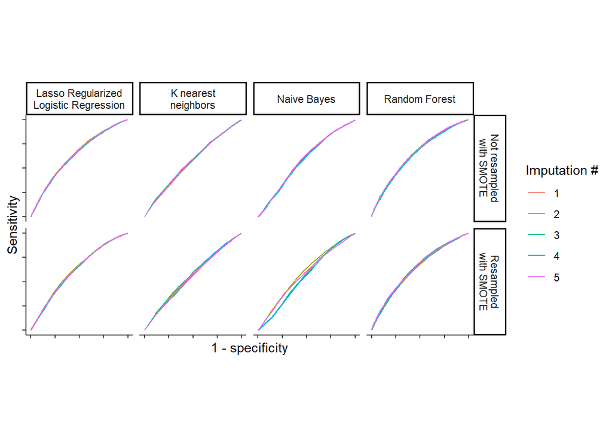

```r
for_roc_panel <- results_frame %>%
  select(-model_fit) %>%
  unnest_wider(results) %>%
  mutate(roc_coords = map(roc_train, ~ tibble(sens = .$sensitivities, m1spec = 1 - .$specificities)),
         imputation_num = factor(imputation_num),
         model = factor(model, c("glmnet", "knn", "naive_bayes", "rf"),
                c("Lasso Regularized\nLogistic Regression", "K nearest\nneighbors",
                  "Naive Bayes", "Random Forest")),
         smote_percent = factor(smote_percent, 0:1, c("Not resampled\nwith SMOTE", "Resampled\nwith SMOTE"))) %>%
  select(c(imputation_num, model, smote_percent, roc_coords)) %>%
  rename(`Imputation #` = imputation_num) %>%
  unnest("roc_coords")

ggplot(for_roc_panel, aes(x = m1spec, y = sens,  color = `Imputation #`)) +
  facet_grid(smote_percent ~ model) +
  geom_line() +
  scale_x_continuous(labels = NULL) +
  scale_y_continuous(labels = NULL) +
  ylab("Sensitivity") +
  xlab("1 - specificity") +
  theme_classic() +
  theme(aspect.ratio = 1)
```

#Figure 2

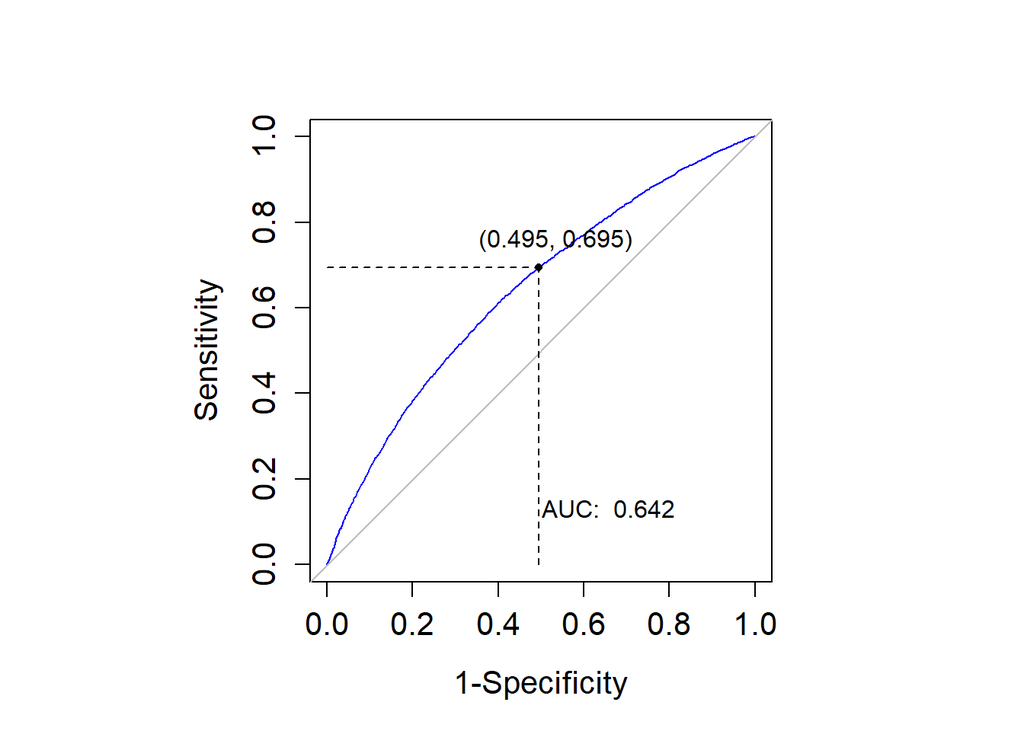

```r
our.plot.optimal.cutpoints <- function (x, legend = TRUE, which = c(1L, 2L), ...) {
  if (!is.numeric(which) || any(which < 1) || any(which >
                                                  3))
    stop("'which' must be in 1:3")
  show <- rep(FALSE, 3)
  show[which] <- TRUE
  op <- par(pty = "s")
  opt.criterion.methods <- c("MCT", "CB", "MaxSpSe", "MaxProdSpSe",
                             "ROC01", "SpEqualSe", "Youden", "MaxEfficiency", "Minimax",
                             "MaxDOR", "MaxKappa", "PROC01", "NPVEqualPPV", "MaxNPVPPV",
                             "MaxSumNPVPPV", "MaxProdNPVPPV", "MinPvalue", "PrevalenceMatching")
  methods <- x[x$methods]
  if (show[3L] & !any(names(methods) %in% opt.criterion.methods)) {
    warning("The plot of the criterion values vis-a-vis all the different test values has beeen selected. None of the selected methods allows this plot. \n",
            call. = FALSE)
    show[3L] = FALSE
  }
  n.levels.cat <- if (is.null(x$levels.cat)) {
    1
  }
  else {
    length(x$levels.cat)
  }
  levels.cat <- if (is.null(x$levels.cat)) {
    NULL
  }
  else {
    x$levels.cat
  }
  n.plots = 0
  for (i in 1:n.levels.cat) {
    for (j in 1:length(methods)) {
      if (length(methods[[j]][[i]][["optimal.cutoff"]][[1]]) ==
          0) {
        if (is.null(x$levels.cat)) {
          cat(paste(names(methods)[j], ": There are no cutoff values that fulfill the criterion \n",
                    sep = ""))
        }
        else {
          cat(paste(names(methods)[j], ": There are no cutoff values that fulfill the criterion for ",
                    levels.cat[i], "\n", sep = ""))
        }
      }
      aux.criterion <- names(methods)[j] %in% opt.criterion.methods
      main <- NULL
      m <- methods[[j]][[i]]
      if (show[1L]) {
        if (n.plots > 0) {
          readline("Press return for next page....")
        }
        plot(1 - m[["measures.acc"]][["Sp"]][, 1], m[["measures.acc"]][["Se"]][,
                                                                               1], xlab = "1-Specificity", ylab = "Sensitivity",
             main = NULL,
             type = "l", cex.lab = 1.3, cex.axis = 1.3,
             ...)
        abline(0, 1, col = "grey")
        legend.text <- paste("AUC: ", paste(round(m[["measures.acc"]][["AUC"]][1], 3), sep = ""))
        legend(0.4, 0.2, legend.text, bty = "n")
        if (length(m[["optimal.cutoff"]][[1]]) != 0) {
          for (k in 1:length(m[["optimal.cutoff"]][[1]])) {
            x <- 1 - m[["optimal.cutoff"]][["Sp"]][[k]]
            y <- m[["optimal.cutoff"]][["Se"]][[k]]
            lines(rep(x, 2), c(0, y), lty = 2)
            lines(c(0, x), rep(y, 2), lty = 2)
            points(x, y, pch = 16, cex = 0.7)
            if (legend) {
              legend.text <- paste("(", round(x, 3),
                                   ", ", round(y, 3), ")", sep = "")
              legend(x, y, legend.text, bty = "n", xjust = 0.5,
                     yjust = 0)
            }
          }
        }
        n.plots = n.plots + 1
      }
      if (show[2L]) {
        if (n.plots > 0) {
          readline("Press return for next page....")
        }
        plot(1 - m[["measures.acc"]][["NPV"]][, 1],
             m[["measures.acc"]][["PPV"]][, 1], xlab = "1 - Negative predictive value",
             ylab = "Positive predictive value", main = paste("PROC Curve. ",
                                                              main, sep = ""), type = "l", cex.lab = 1.3,
             cex.axis = 1.3, xlim = c(0, 1), ylim = c(0,
                                                      1), ...)
        if (length(m[["optimal.cutoff"]][[1]]) != 0) {
          for (k in 1:length(m[["optimal.cutoff"]][[1]])) {
            x <- 1 - m[["optimal.cutoff"]][["NPV"]][[k]]
            y <- m[["optimal.cutoff"]][["PPV"]][[k]]
            lines(rep(x, 2), c(0, y), lty = 2)
            lines(c(0, x), rep(y, 2), lty = 2)
            points(x, y, pch = 16, cex = 0.7)
            if (legend) {
              legend.text <- paste("(", round(x, 2),
                                   ", ", round(y, 2), ")", sep = "")
              legend(x, y, legend.text, bty = "n", xjust = 0.5,
                     yjust = 0)
            }
          }
        }
        n.plots = n.plots + 1
      }
      if (aux.criterion & show[3L]) {
        if (n.plots > 0) {
          readline("Press return for next page....")
        }
        plot(m[["measures.acc"]][["cutoffs"]], m[["criterion"]],
             xlab = "Cutoffs values", ylab = "Optimal criterion",
             main = main, type = "l", cex.lab = 1.3, cex.axis = 1.3,
             ...)
        if (length(m[["optimal.cutoff"]][[1]]) != 0) {
          for (k in 1:length(m[["optimal.cutoff"]][[1]])) {
            x <- m[["optimal.cutoff"]][["cutoff"]][[k]]
            y <- m[["optimal.criterion"]][[1]]
            lines(rep(x, 2), c(0, y), lty = 2)
            lines(c(0, x), rep(y, 2), lty = 2)
            points(x, y, pch = 16, cex = 0.7)
            if (legend) {
              legend.text <- paste("(", round(x, 3),
                                   ", ", round(y, 3), ")", sep = "")
              legend(x, y, legend.text, bty = "n", xjust = 0.5,
                     yjust = 0)
            }
          }
        }
        n.plots = n.plots + 1
      }
    }
  }
  par(op)
}

frame_to_pull <- results_frame %>%
  unnest_wider(results)

our.plot.optimal.cutpoints(frame_to_pull[3, 7][[1]][[1]], which = 1, col = "blue")
title(" ")
```

# Testing

```r
optimal_cut <- frame_to_pull[3, 7][[1]][[1]]$MaxKappa$Global$optimal.cutoff$cutoff
optimal_cut
```

```
## [1] 0.364
```

```r
chosen_model <- frame_to_pull[3, 4][[1]][[1]]
chosen_model
```

```
## Random Forest
##
## 4200 samples
##   78 predictor
##    2 classes: 'Adenoma', 'Nonadenoma'
##
## Pre-processing: centered (106), scaled (106)
## Resampling: Cross-Validated (5 fold, repeated 5 times)
## Summary of sample sizes: 3360, 3360, 3359, 3360, 3361, 3359, ...
## Resampling results across tuning parameters:
##
##   mtry  ROC        Sens       Spec
##     2   0.6562441  0.1599167  0.9418474
##    54   0.6442856  0.3999943  0.7883797
##   106   0.6423118  0.4029637  0.7845093
##
## Sens was used to select the optimal model using the largest value.
## The final value used for the model was mtry = 106.
```

```r
clean_testing <- select(testing, !c("procedure_uid", "any_adenoma"))

impute_testing <- mice(data = clean_testing, m = 1, pred=quickpred(clean_testing, mincor = 0.3), seed = 13)
imputed_testing <- complete(impute_testing, 1)

predictions <- factor(if_else(predict(chosen_model, newdata = imputed_testing, type = "prob")[, 1] > optimal_cut, 1, 2), 1:2, c("Adenoma", "Nonadenoma"))
pred_probs <- predict(chosen_model, newdata = imputed_testing, type = "prob")[, 1]
actual_testing <- imputed_testing$f_any_adenoma

cm <- confusionMatrix(predictions, actual_testing)
roc_testing <- pROC::roc(actual_testing, pred_probs, levels = c("Adenoma", "Nonadenoma"), direction = ">")
```

# Figure 3

```r
roc_testing
```

```
##
## Call:
## roc.default(response = actual_testing, predictor = pred_probs,     levels = c("Adenoma", "Nonadenoma"), direction = ">")
##
## Data: pred_probs in 988 controls (actual_testing Adenoma) > 1667 cases (actual_testing Nonadenoma).
## Area under the curve: 0.6531
```

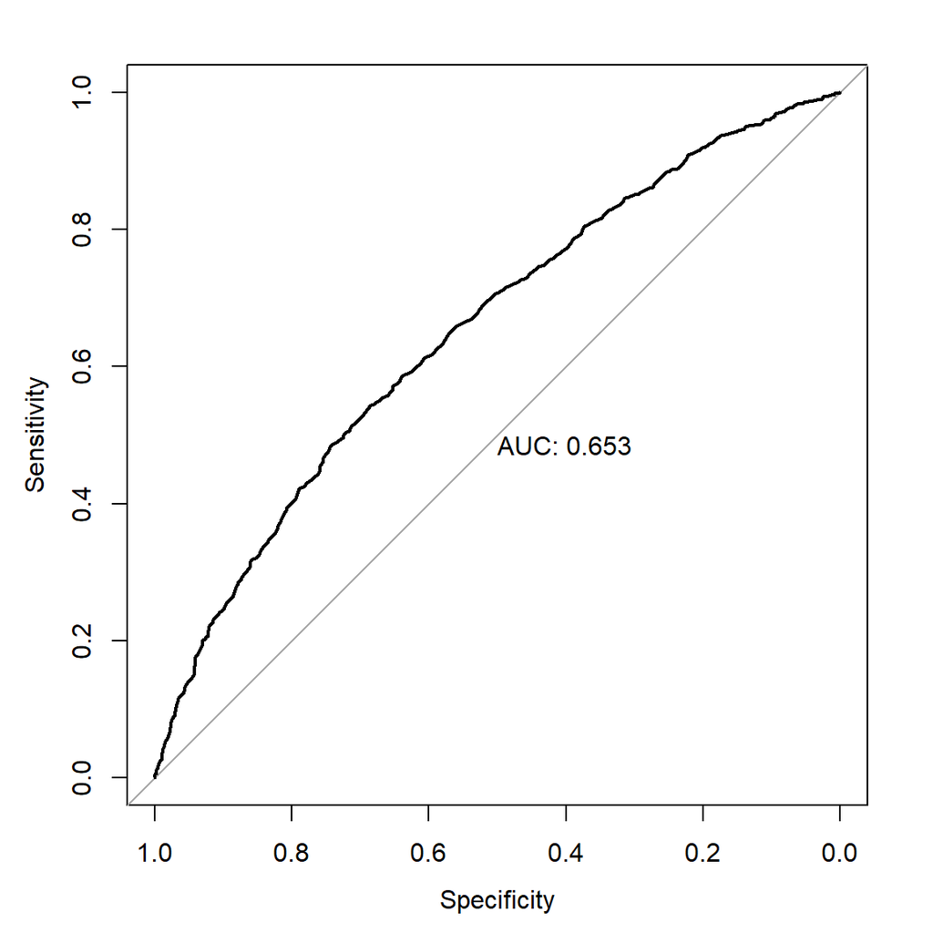

```r
plot(roc_testing, xlim = c(1, 0), print.auc = T)
```

# Table 5a

```r
cm$table
```

```
##             Reference
## Prediction   Adenoma Nonadenoma
##   Adenoma        705        813
##   Nonadenoma     283        854
```

# Table 5b

```r
as_tibble(cm$byClass[1:4], rownames = "Statistic") %>%
  mutate(value = format(round(value, 2), nsmall = 2)) %>%
  flextable() %>%
  set_header_labels(Statistic = " ", value = "Value")
```

|  | Value |
| --- | --- |
| Sensitivity | 0.71 |
| Specificity | 0.51 |
| Pos Pred Value | 0.46 |
| Neg Pred Value | 0.75 |

1. Analysis files (scripts, data, output)
2. Research paper
3. Presentation

The research paper will be a documentation of the analyses carried out, information on the dataset, the scientific background about this dataset and research questions carried out, as well as references. Your paper will be formatted as if it were a research manuscript to be submitted to a journal, similar to what you have read for your article evaluations. That is, it should include the following sections:

1. Abstract
- Brief, one paragraph summary of your work. Should include very brief mention of research question(s), scientific/public health background of your question(s), the dataset itself, methods used for analysis, and main results of your analysis
2. Introduction
- Motivation to scientific and public health background of your research question
- Research question(s)
- Very brief mention of previous machine learning analyses related to your question(s)
3. Methods
- First: description of your dataset (where did it come from, who is the population of interest, sampling method, etc.) with a discussion of the variables of interest in the data and what role they play in your research question(s)
- Second: your analysis pipeline. The amount of detail to provide should be the amount needed to replicate your work. **Be sure to cite the version of R you are using for your analyses, , including a citation entry for R in the works cited page.** You can find the entry to use using the `citation` function in R.
4. Results
- First: include summary statistics and visualizations of your data. Make sure these are **related to your research question(s)**.
- Second: include the results from your prediction analyses. For all metrics relating to prediction performance, **make sure to include a measure of accuracy/error and corresponding measure of the uncertainty for this accuracy/error (ex. standard error)**
  - Use tables and (if useful) visualizations when reporting these numbers.
5. Discussion
- Provide interpretations of your results and how they relate back to your research question(s).
  - Make sure to also **relate these results to the broader scientific and public health considerations of your questions (what populations do your results pertain to? Who do they not and why? Why is important to consider who benefits from your ability to predict?).**
- Mention some future directions that may be of interest for analyses related to your research question(s), which may be related to limitations in your analyses.

Include a works cited page with corresponding in-line citations where appropriate. Use any of the standard citation methods you would like (just stay consistant, e.g MLA, APA, etc.). There are no formatting requirements for this project, or page length requirements (though please use either 11 or 12 point font with a standard font style appropriate for an academic setting).

The presentation will be a set of slides based on your analyses described in your paper. You should touch on all parts in your paper, with a focus on the methods and results sections.

Finally, your analysis files (scripts, data, output) should be contained in a file directory which is well organized to facilitate reproducibility. All tables and figures mentioned in your paper or presentation **should be created and formatted in code**, the exception being changes to the sizes of rows and columns in your tables. The main goal: I should be able to reproduce all results simply by running your code with the loaded packages and version of R.

All files, including your paper and slides, will be uploaded to the group GitHub repository as the method for submission.